# Final Project

## Introduction - What is the internet

- The internet is a system of global networks that transmits data and connect devices globally
  - It is a network of networks
  - Invented in the 1960s, this technological phenomennon quickly rose to popularity and now dominates households, schools, and workplaces.
  - Its prevalence in our everyday life and our reliance on it prompts us to question what affects our society’s usage of internet.

## Introduction - Cont.

For our purposes, we will be using the data sets from the CIA world fact book to compare each country

- Internet user: “compares the number of users within a country that access the Internet”
- Population: “compares estimates from the US Bureau of the Census based on statistics from population censuses, vital statistics registration systems, or sample surveys pertaining to the recent past and on assumptions about future trends”

## Objectives

In this presentation we will:

- Q1: Define how we measure internet usage in a country
- Q2: Compare internet usage within regions
- Q3: Define concepts such as democracy, education, economy, and health in order to assess their impact on internet usage

## Q1 - How do we define internet usage in a country?

- Each country has a different population. Thus, to ensure that our comparisons are not affected by population, we defined internet usage rate as:
  - number of internet users / population

```
## Observations: 223
## Variables: 4
## $ Country             <chr> "Pitcairn Islands", "Bermuda", "Liechtenst...
## $ `INTERNET USERS`    <dbl> 54, 69126, 37214, 2673000, 329967, 5424169...
## $ POPULATION          <dbl> 54, 70864, 38244, 2747943, 339747, 5605948...
## $ percentage_of_users <dbl> 1.0000000, 0.9754741, 0.9730677, 0.9727276...
```

## Q2 - Internet usage by regions of the world: World Map

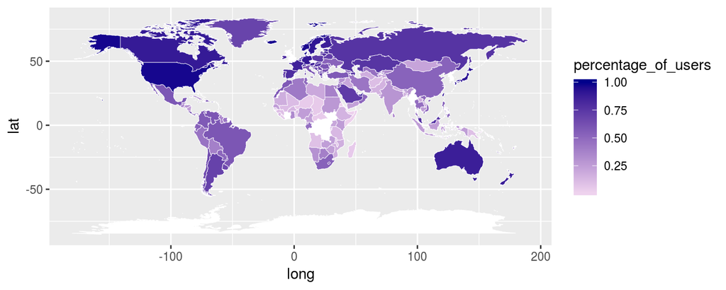

## Q2 - Internet use by regions of the world: Boxplot

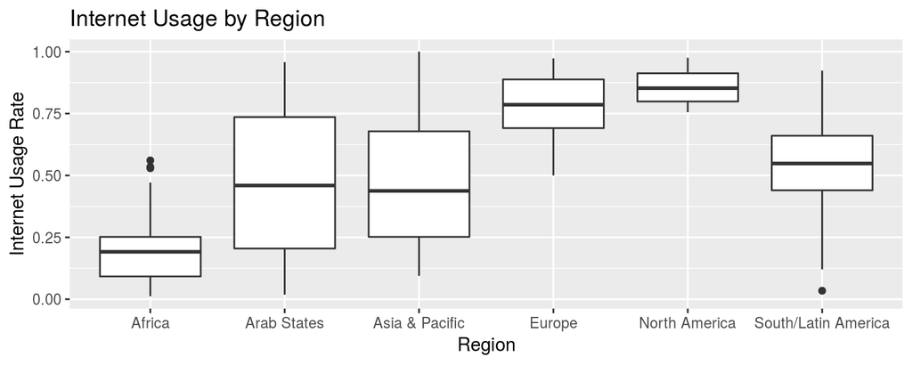

## Q3 - How we defined Economy:

- Defined the economy of a country through their GDP per Capita
- What is GDP per Capita?

```r
glimpse(gdp_internet)
```

```
## Observations: 219
## Variables: 5
## $ Country             <chr> "Bermuda", "Liechtenstein", "West Bank", "...
## $ `INTERNET USERS`    <dbl> 69126, 37214, 2673000, 329967, 5424169, 51...
## $ POPULATION          <dbl> 70864, 38244, 2747943, 339747, 5605948, 53...
## $ percentage_of_users <dbl> 0.9754741, 0.9730677, 0.9727276, 0.9712139...
## $ GDP_PER_CAPITA      <dbl> 99400, 139100, 4300, 51800, 49900, 71800, ...
```

## Q3 - Impact of Economy on Internet Use:

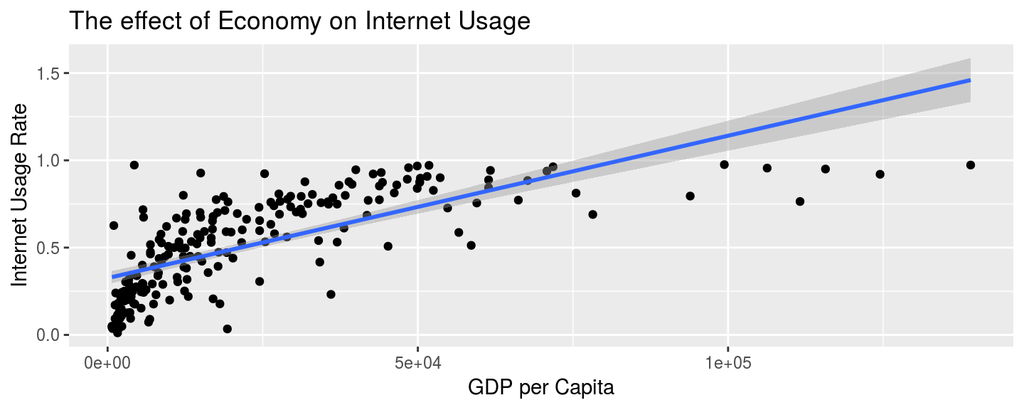

## Q3 - How we defined Health:

- Defined the health of a country through the life expectancy of their citizens

```r
glimpse(life_internet)
```

```
## Observations: 215
## Variables: 6
## $ Country             <chr> "Bermuda", "Liechtenstein", "West Bank", "...
## $ `INTERNET USERS`    <dbl> 69126, 37214, 2673000, 329967, 5424169, 51...
## $ POPULATION          <dbl> 70864, 38244, 2747943, 339747, 5605948, 53...
## $ percentage_of_users <dbl> 0.9754741, 0.9730677, 0.9727276, 0.9712139...
## $ `(YEARS)`           <dbl> 81.4, 81.9, 75.2, 83.1, 79.5, 81.9, 79.0, ...
## $ years_group         <chr> ">70", ">70", ">70", ">70", ">70", ">70", ...
```

## Q3 - Impact of Health on Internet Use:

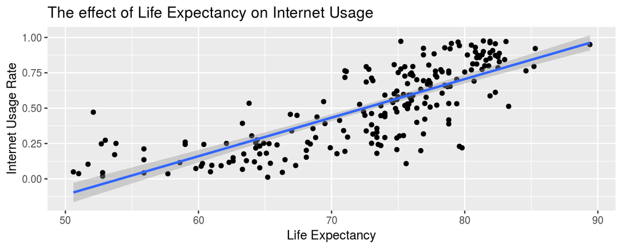

## Q3 - How we defined Democracy:

- We defined the democracy of a country based on the score that they received
- What does the score represent?

```r
glimpse(democracy)
```

```
## Observations: 155
## Variables: 6
## $ Country             <chr> "Iceland", "Denmark", "Norway", "Bahrain",...
## $ `INTERNET USERS`    <dbl> 329967, 5424169, 5122904, 1351326, 567698,...
## $ POPULATION          <dbl> 339747, 5605948, 5320045, 1410942, 594130,...
## $ percentage_of_users <dbl> 0.9712139, 0.9675739, 0.9629437, 0.9577474...
## $ Score               <dbl> 9.58, 9.22, 9.87, 2.71, 8.81, 8.53, 7.88, ...
## $ Category            <chr> "Full democracy", "Full democracy", "Full ...
```

## Q3 - Impact of Democracy on Internet Usage:

- Coloured based on type of government

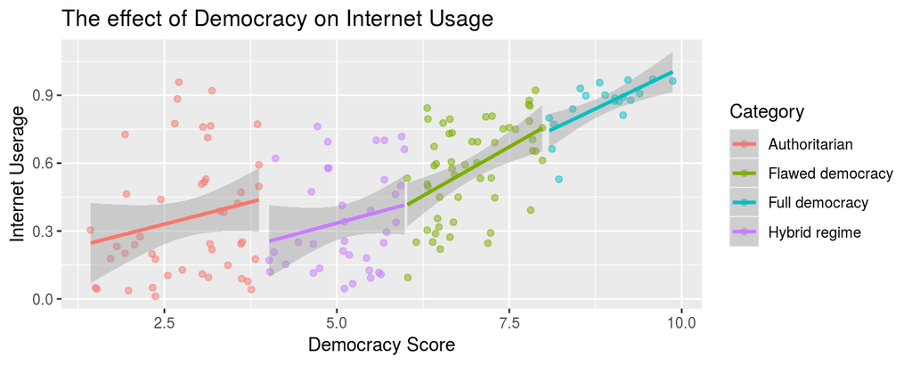

## Q3 - How we defined Education

```r
glimpse(education_gdp)
```

```
## Observations: 171
## Variables: 5
## $ Country             <chr> "Bermuda", "Liechtenstein", "Iceland", "De...
## $ percentage_of_users <dbl> 0.9754741, 0.9730677, 0.9712139, 0.9675739...
## $ `(% OF GDP)`        <dbl> 2.6, 2.1, 7.6, 8.7, 6.9, 2.6, 3.7, 1.6, 6....
## $ GDP_PER_CAPITA      <dbl> 99400, 139100, 51800, 49900, 71800, 48500,...
## $ edu_gdp             <dbl> 258440, 292110, 393680, 434130, 495420, 12...
```

## Q3 - Impact of Education on Internet Usage:

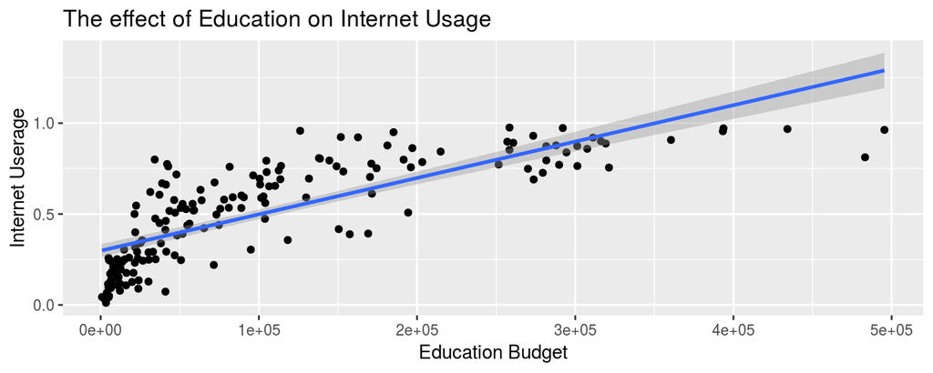

## Q3 - Conclusion

```
 - Summary
```

There is a positive correlation between the percentage of internet users and country’s democracy score, education budget, life expectancy, and GDP.

Regions with the relatively higher median percentage of internet users include more countries with higher GDP and other three factors

```
  - Concern
```

Date of information is different in different data

Is GDP a confounding variable?